# Corrección de datos

## Tiempo inicio-último seguimiento

Podemos sustituirlo por la media, aunque eso no es la solución ideal

```r
Tiempo.medio = mean(chuvi$Tiempo.inicio.ultimo.seguimiento, na.rm=T)
chuvi$Tiempo.inicio.ultimo.seguimiento.fix = ifelse(is.na(chuvi$Tiempo.inicio.ultimo.seguimiento), Tiempo.medio, chuvi$Tiempo.inicio.ultimo.seguimiento)
summary(chuvi$Tiempo.inicio.ultimo.seguimiento.fix)
```

```
   Min. 1st Qu.  Median    Mean 3rd Qu.    Max.
   1812    2131    2131    2131    2131    2512
```

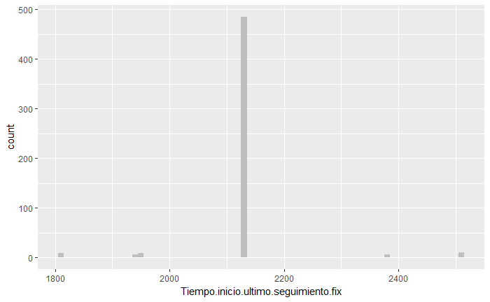

```r
library(ggplot2)
ggplot(chuvi) +
geom_histogram(aes(x=Tiempo.inicio.ultimo.seguimiento.fix),
binwidth=10, fill="gray")
```

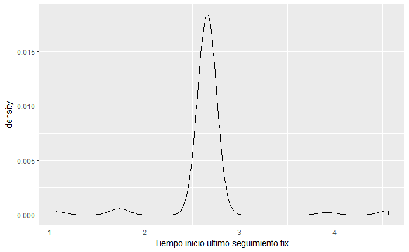

```r
library(ggplot2)
library(scales)
ggplot(chuvi) + geom_density(aes(x=Tiempo.inicio.ultimo.seguimiento.fix)) +
scale_x_continuous(labels=time)
```

Decididamente no es la solución más ideal, pero hasta que le pregunte a la profe cómo puedo arreglarlos de forma que dependan de otros datos, podemos dejarlo así.

## Estímulos

Podemos asumir que todos los que faltan son ceros

ATENCIÓN: hemos sustituido los valores de VA Y MA Y VD Y VI Y TODOS ESOS por ceros PERO EN REALIDAD NO PODRÍA.

```r
chuvi$STIMA.fix = ifelse(is.na(chuvi$STIMA),0,chuvi$STIMA)
summary(chuvi$STIMA.fix)
```

```
   Min. 1st Qu.  Median    Mean 3rd Qu.    Max.
    0.0     0.0     5.0    30.4    63.0   100.0
```

```r
chuvi$MSA.fix = ifelse(is.na(chuvi$MSA),0,chuvi$MSA)
summary(chuvi$MSA.fix)
```

```
   Min. 1st Qu.  Median    Mean 3rd Qu.    Max.
 0.0000  0.3500  0.3500  0.3219  0.3500  0.6000
```

```r
chuvi$VA.fix = ifelse(is.na(chuvi$VA),0,chuvi$VA)
summary(chuvi$VA.fix)
```

```
   Min. 1st Qu.  Median    Mean 3rd Qu.    Max.
  0.000   2.000   2.000   2.112   2.500   4.500
```

```r
chuvi$STIMVD.fix = ifelse(is.na(chuvi$STIMVD),0,chuvi$STIMVD)
summary(chuvi$STIMVD.fix)
```

```
   Min. 1st Qu.  Median    Mean 3rd Qu.    Max.
   0.00    0.00    0.00   34.33   91.00  100.00
```

```r
chuvi$MSVD.fix = ifelse(is.na(chuvi$MSVD),0,chuvi$MSVD)
summary(chuvi$MSVD.fix)
```

```
   Min. 1st Qu.  Median    Mean 3rd Qu.    Max.
  0.350   0.350   0.350   0.407   0.500   1.000
```

```r
chuvi$VD.fix = ifelse(is.na(chuvi$VD),0,chuvi$VD)
summary(chuvi$VD.fix)
```

```
   Min. 1st Qu.  Median    Mean 3rd Qu.    Max.
  0.250   2.500   2.500   2.807   3.000   7.000
```

```r
chuvi$STIMVI.fix = ifelse(is.na(chuvi$STIMVI),0,chuvi$STIMVI)
summary(chuvi$STIMVI.fix)
```

```
   Min. 1st Qu.  Median    Mean 3rd Qu.    Max.
    0.0     0.0     0.0    11.6     0.0   100.0
```

```r
chuvi$MSVI.fix = ifelse(is.na(chuvi$MSVI),0,chuvi$MSVI)
summary(chuvi$MSVI.fix)
```

```
   Min. 1st Qu.  Median    Mean 3rd Qu.    Max.
0.00000 0.00000 0.00000 0.05468 0.00000 1.00000
```

```r
chuvi$VI.fix = ifelse(is.na(chuvi$VI),0,chuvi$VI)
summary(chuvi$VI.fix)
```

```
   Min. 1st Qu.  Median    Mean 3rd Qu.    Max.
 0.0000  0.0000  0.0000  0.3817  0.0000  7.0000
```

Ahora tenemos que recuperar los factores

```r
chuvi$VA.fix.factor = as.factor(chuvi$VA.fix)
summary(chuvi$VA.fix.factor)
```

```
  0 1.5   2 2.5   3 3.5   4 4.5
 71  10 184 188   5  55   7   4
```

```r
chuvi$MSA.fix.factor = as.factor(chuvi$MSA.fix)
summary(chuvi$MSA.fix.factor)
```

```
   0 0.35  0.5  0.6
  71  392   51   10
```

```r
chuvi$VD.fix.factor = as.factor(chuvi$VD.fix)
summary(chuvi$VD.fix.factor)
```

```
0.25    2  2.5    3  3.5    4  4.5    7
   8   56  263   69   93   11   18    6
```

```r
chuvi$MSVD.fix.factor = as.factor(chuvi$MSVD.fix)
summary(chuvi$MSVD.fix.factor)
```

```
0.35  0.5  0.6 0.75    1
 366  126   24    1    7
```

```r
chuvi$VI.fix.factor = as.factor(chuvi$VI.fix)
summary(chuvi$VI.fix.factor)
```

```
  0   2 2.5 3.5 4.5   7
460  27  16   6   8   7
```

```r
chuvi$MSVI.fix.factor = as.factor(chuvi$MSVI.fix)
summary(chuvi$MSVI.fix.factor)
```

```
   0 0.35  0.5    1
 460   49    7    8
```

## Choque y ATP

Podemos asumir que son ceros también

```r
chuvi$Choque.fix = ifelse(is.na(chuvi$Choque),0,chuvi$Choque)
summary(chuvi$Choque.fix)
```

```
   Min. 1st Qu.  Median    Mean 3rd Qu.    Max.
 0.0000  0.0000  0.0000  0.1926  0.0000 20.0000
```

```r
chuvi$ATP.fix = ifelse(is.na(chuvi$ATP),0,chuvi$ATP)
summary(chuvi$ATP.fix)
```

```
    Min.  1st Qu.   Median     Mean  3rd Qu.     Max.
   0.000    0.000    0.000    3.865    0.000 1107.000
```

## Conversión de datos

Queremos eliminar los NAs de la supervivencia, pero para eso necesitamos calcular cuánto tiempo le queda de vida desde la fecha actual hasta la final que le hemos puesto calculada de media. ¿Cómo podemos hacerlo?

Mierda soy idiota.

```r
Tiempo.vida = ifelse((chuvi$Tiempo.inicio.ultimo.seguimiento.fix - chuvi$Tiempo.desde.implante) < 0, 0, chuvi$Tiempo.inicio.ultimo.seguimiento.fix - chuvi$Tiempo.desde.implante)
summary(Tiempo.vida)
```

```
   Min. 1st Qu.  Median    Mean 3rd Qu.    Max.
    0.0     0.0   346.9   508.1   853.6  2068.0
```

```r
chuvi$Tiempo.hasta.ultimo.seguimiento.fix = ifelse(is.na(chuvi$Tiempo.hasta.ultimo.seguimiento), Tiempo.vida, chuvi$Tiempo.hasta.ultimo.seguimiento)
summary(chuvi$Tiempo.hasta.ultimo.seguimiento.fix)
```

```
   Min. 1st Qu.  Median    Mean 3rd Qu.    Max.
    0.0     0.0   346.9   508.1   853.6  2068.0
```

Esto está obviamente mal porque no es la mejor aproximación que podíamos haber hecho, pero para empezar a trabajar con los datos nos sirve.

## Corregimos la supervivencia

```r
summary(chuvi$Supervivencia.factor)
```

```
 entre 12 y 6 entre 18 y 12  entre 6 y 3      más de 18    menos de 3          NA's
            6             7             2           263             1           245
```

```r
breaks = c(0,89,179,359,539,3000)
Supervivencia.cor = cut(Tiempo.vida, breaks=breaks, labels=c("menos de 3", "entre 6 y 3", "entre 12 y 6", "entre 18 y 12", "más de 18"), include.lowest=T)
Supervivencia.cor = as.character(Supervivencia.cor)
summary(Supervivencia.cor)
```

```
   Length     Class      Mode
      524 character character
```

```r
chuvi$Supervivencia.factor = as.character(chuvi$Supervivencia.factor)
chuvi$Supervivencia.factor.fix = ifelse(is.na(chuvi$Supervivencia.factor),Supervivencia.cor,chuvi$Supervivencia.factor)
chuvi$Supervivencia.factor.fix = as.factor(chuvi$Supervivencia.factor.fix)
summary(chuvi$Supervivencia.factor.fix)
```

```
 entre 12 y 6 entre 18 y 12   entre 6 y 3  entre 6 y 3      más de 18    menos de 3
           33            20            17             2           295           157
```

Ahora ya tenemos los datos un poco más bonitos. Estaría bien corregir también los meses normales.

## Meses

```r
chuvi$x3M.fix = as.character(chuvi$x3M.factor)
Sup.3.M = ifelse(Tiempo.vida < 89, "NO", "SI")
chuvi$x3M.fix = ifelse(is.na(chuvi$x3M.fix),Sup.3.M,chuvi$x3M.fix)
chuvi$x3M.fix = as.factor(chuvi$x3M.fix)
summary(chuvi$x3M.fix)
```

```
 NO  SI
 69 455
```

```r
chuvi$x6M.fix = as.character(chuvi$x6M.factor)
Sup.6.M = ifelse(Tiempo.vida < 179, "NO", "SI")
chuvi$x6M.fix = ifelse(is.na(chuvi$x6M.fix),Sup.6.M,chuvi$x6M.fix)
chuvi$x6M.fix = as.factor(chuvi$x6M.fix)
summary(chuvi$x6M.fix)
```

```
 NO  SI
104 420
```

```r
chuvi$x12M.fix = as.character(chuvi$x12M.factor)
Sup.12.M = ifelse(Tiempo.vida < 359, "NO", "SI")
chuvi$x12M.fix = ifelse(is.na(chuvi$x12M.fix),Sup.12.M,chuvi$x12M.fix)
chuvi$x12M.fix = as.factor(chuvi$x12M.fix)
summary(chuvi$x12M.fix)
```

```
 NO  SI
170 354
```

```r
chuvi$x18M.fix = as.character(chuvi$x18M.factor)
Sup.18.M = ifelse(Tiempo.vida < 89, "NO", "SI")
chuvi$x18M.fix = ifelse(is.na(chuvi$x18M.fix),Sup.18.M,chuvi$x18M.fix)
chuvi$x18M.fix = as.factor(chuvi$x18M.fix)
summary(chuvi$x18M.fix)
```

```
 NO  SI
172 352
```

## Datos corregidos

Podemos explorar los datos corregidos para ver qué tal han salido

## Factor de supervivencia

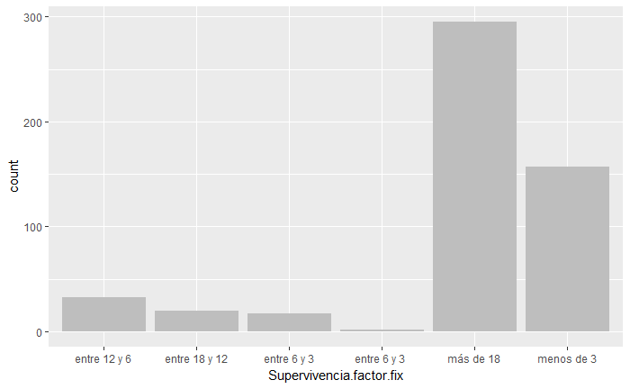

```r
ggplot(chuvi) + geom_bar(aes(x=Supervivencia.factor.fix), fill="gray")
```

Huy, ahí habría que corregir ese entre 6 y 3.

## Supervivencia VS. número de cámaras

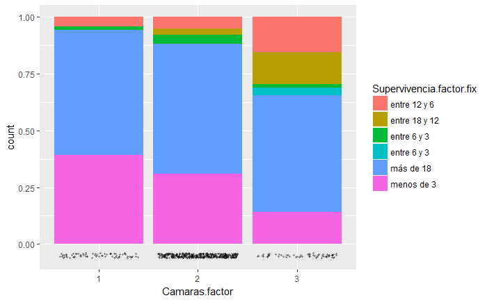

```r
ggplot(chuvi, aes(x=Camaras.factor)) +
geom_bar(aes(fill=Supervivencia.factor.fix), position="fill") +
geom_point(aes(y=-0.05), size=0.75, alpha=0.3,
position=position_jitter(h=0.01))
```

Es curioso, cuanto menos.

Las gráficas a continuación son una clara muestra de que hay formas mejores de estimar el tiempo entre inicio y último seguimiento, pero que al fin y al cabo funcionan.

## Estimulaciones VS. tiempo entre inicio y último seguimiento

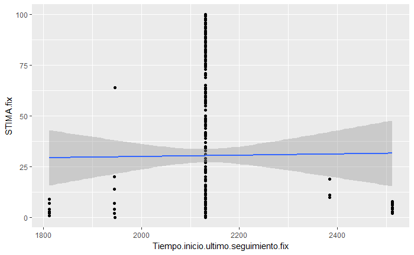

```r
library(ggplot2)
ggplot(chuvi, aes(x=Tiempo.inicio.ultimo.seguimiento.fix, y=STIMA.fix)) + geom_point() + stat_smooth(method="lm")
```

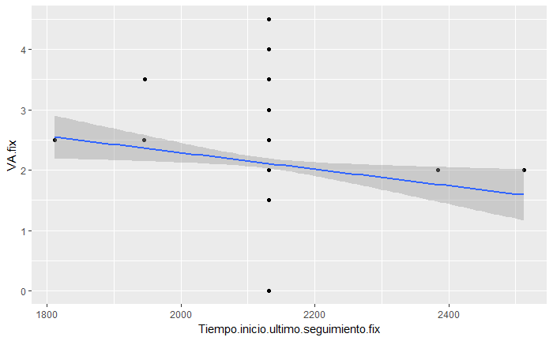

```r
library(ggplot2)
ggplot(chuvi, aes(x=Tiempo.inicio.ultimo.seguimiento.fix, y=VA.fix)) + geom_point() + stat_smooth(method="lm")
```

[figure not shown]

```r
ggplot(chuvi, aes(x=Voltaje.bateria, y=as.numeric(x3M.fix))) +
geom_point(position=position_jitter(w=0.05, h=0.05)) +
geom_smooth()
```

## Voltaje batería VS. Supervivencia en meses

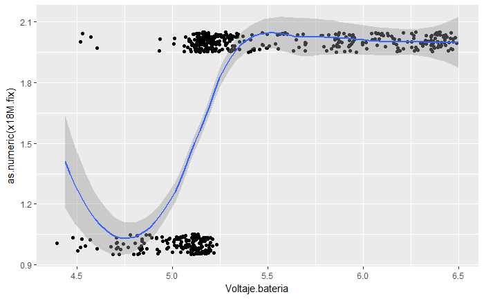

```r
ggplot(chuvi, aes(x=Voltaje.bateria, y=as.numeric(x18M.fix))) +
geom_point(position=position_jitter(w=0.05, h=0.05)) +
geom_smooth()
```

## Tiempo hasta el último seguimiento VS. voltaje de la batería

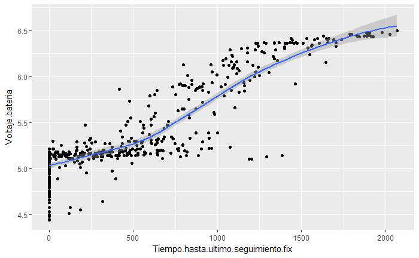

```r
ggplot(chuvi, aes(x=Tiempo.hasta.ultimo.seguimiento.fix, y=Voltaje.bateria)) +
geom_point() + geom_smooth()
```

Esta gráfica se parece bastante a la que teníamos con pocos datos, pero con muchos más.

## Choque y ATP

El chocque y ATP sabemos que son importantes, así que vamos a ver si tienen alguna relación.

```r
cor(chuvi$Tiempo.inicio.ultimo.seguimiento.fix,chuvi$Choque.fix, use="complete.obs")
```

```
[1] 6.138279e-18
```

Hahahá

```r
cor(chuvi$Tiempo.hasta.ultimo.seguimiento.fix,chuvi$Choque.fix, use="complete.obs")
```

```
[1] -0.08734264
```

Hahá

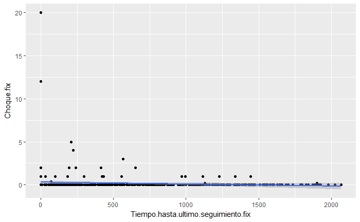

```r
library(ggplot2)
ggplot(chuvi, aes(x=Tiempo.hasta.ultimo.seguimiento.fix, y=Choque.fix)) + geom_point() + stat_smooth(method="lm")
```

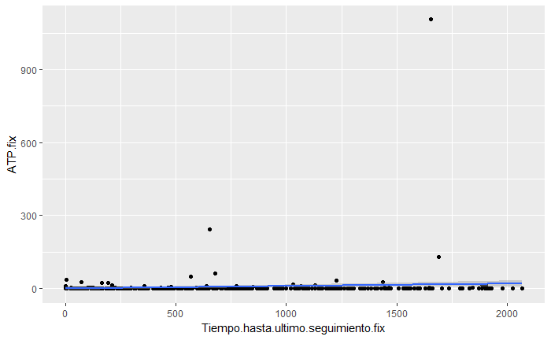

```r
library(ggplot2)
ggplot(chuvi, aes(x=Tiempo.hasta.ultimo.seguimiento.fix, y=ATP.fix)) + geom_point() + stat_smooth(method="lm")
```

Lloro.

Bueno pues nada.